# Developing Machine Learning Software

## Programming Language for Machine Learning

The most popular programming languages for machine learning (not necessarily in this order):

- [Python](http://www.python.org/): scripting language, it is easy to wrap C/C++ libraries, great libraries
- [Julia](http://julialang.org/): brand-new, awesome, efficient, designed for scientific programming
- [Octave](http://www.gnu.org/software/octave/): free Matlab clone
- C/C++: efficient, **general** purpose language
- Java: web applications, large scale and distributed systems
- ...

It helps **a lot** to use libraries that have support for linear algebra (matrices and vectors), e.g.

- Python: [NumPy](http://www.numpy.org/)
- Julia: builtin
- Octave: builtin
- C++: [Eigen **3**](http://eigen.tuxfamily.org/index.php?title=Main_Page)
- C/Fortran: [BLAS](http://en.wikipedia.org/wiki/Basic_Linear_Algebra_Subprograms) ([OpenBLAS](http://www.openblas.net/), CBLAS, ...), [LAPack](http://www.netlib.org/lapack/)
- Java: [JBlas](http://mikiobraun.github.io/jblas/) (BLAS wrapper), [Jama](http://math.nist.gov/javanumerics/jama/)

## Python

Python is possibly the best choice for the programming tasks today since there are many libraries that are great for machine learning, for example

- [NumPy](http://www.numpy.org/) for linear algebra
- [Matplotlib](http://matplotlib.org/) for visualization
- not required in this lecture: SciPy, Pandas, Scikit Learn, Theano, ...

In addition, you can work interactively with [IPython](http://ipython.org/) notebooks. Examples can be found at the [IPython Notebook Viewer](http://nbviewer.ipython.org/).

## Setup Python Environment

Required packages to run this notebook:

- Python
- IPython - interactive Python shell
- IPython notebooks - IPython for the browser
- NumPy - linear algebra library
- Matplotlib - plotting library

Scientific Python Distributions (available for every platform)

- **[Anaconda](https://store.continuum.io/cshop/anaconda/)**
- [Enthought Python Distribution](https://www.enthought.com/products/epd/)

## Introductions to Python and Scientific Programming

- **[Python Scientific Lecture Notes](http://scipy-lectures.github.io/)**
- [General Introduction to Python](http://www.diveintopython.net/)
- [Interactive Python Tutorial](http://www.learnpython.org/)
- [NumPy for Matlab Users](http://wiki.scipy.org/NumPy_for_Matlab_Users)

## IDEs

- Platform independend: [PyCharm](http://www.jetbrains.com/pycharm/), [Eclipse](http://www.eclipse.org/) with [PyDev](http://pydev.org/)
- Mac OS X: [TextMate](https://github.com/textmate/textmate)

# IPython

Document your code with

- **Markdown** and
- *LaTeX* formulas:

\[\sigma = \sqrt{\sum_{n=1}^N \left( x_n - \mu \right)^2}\]

```python
# IPython magic: load numpy and matplotlib
%pylab inline
```

```python
%timeit np.random.randn(10)
```

```
1000000 loops, best of 3: 960 ns per loop
```

```python
%run test.py
```

```
ERROR: File `u'test.py'` not found.
```

```python
cat README.md
```

```
Machine Learning Tutorials
==========================

These are IPython notebooks for the tutorials of the machine learning course
at the University of Bremen.

You can view the notebooks and the corresponding slides
[here](http://alexanderfabisch.github.io/ml_tutorials/).

Requirements
------------

The following packages are required to use these notebooks:

* Python
* IPython - interactive Python shell
* IPython notebooks - IPython for the browser
* NumPy - linear algebra library
* Matplotlib - plotting library

For Windows: use the [Enthought Python Distribution](https://www.enthought.com/products/epd/).
```

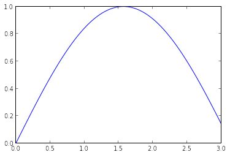

```python
plot(linspace(0, 3, 100), sin(linspace(0, 3, 100)))
```

```python
np.random.randn(2, 2)
```

```
array([[-0.51880155,  1.97473863],
       [ 0.02594467,  0.94626438]])
```

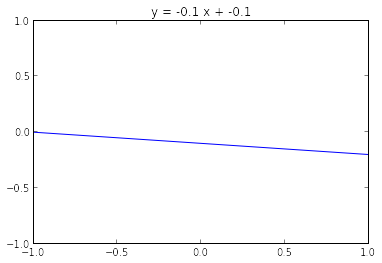

```python
from IPython.html.widgets import interactive


def iwidget(w, b):
    x = np.linspace(-1, 1, 201)
    y = w * x + b
    plt.plot(x, y)
    plt.xlim((-1, 1))
    plt.ylim((-1, 1))
    plt.title("y = %g x + %g" % (w, b))


interactive(iwidget, w=(-1, 1, 0.1), b=(-0.5, 0.5, 0.1))
```

# NumPy

## Creating ndarrays

ndarrays can have n dimensions but most of them have 1 (vector) or 2 (matrix)

```python
a = np.array([0, 1, 2])
a
```

```
array([0, 1, 2])
```

Vector of ones \(\boldsymbol{1}\)

```python
b = np.ones(3)
b
```

```
array([ 1.,  1.,  1.])
```

Vector of zeros \(\boldsymbol{0}\)

```python
c = np.zeros(3)
c
```

```
array([ 0.,  0.,  0.])
```

Identity matrix \(\boldsymbol{I}\)

```python
D = np.eye(2)
D
```

```
array([[ 1.,  0.],
       [ 0.,  1.]])
```

iid. Gaussian samples

```
array([[ 1.5665339 ,  0.43694552],
       [-1.28266065,  0.2287341 ],
       [ 0.8974332 ,  0.76310245],
       ...,
       [-0.97548267,  0.35538135],
       [-0.28945761, -0.38964488],
       [-0.47793939, -1.96564353]])
```

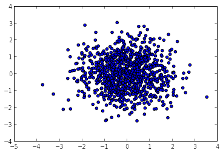

```python
E = np.random.randn(1000, 2)
scatter(E[:, 0], E[:, 1])
E
```

Matrix multiplication

```python
E.dot(D)
```

```
array([[ 1.5665339 ,  0.43694552],
       [-1.28266065,  0.2287341 ],
       [ 0.8974332 ,  0.76310245],
       ...,
       [-0.97548267,  0.35538135],
       [-0.28945761, -0.38964488],
       [-0.47793939, -1.96564353]])
```

**Note:** `*` is **not** the matrix multiplication! It is the component-wise multiplication!

```python
A = np.array([[0, 1], [2, 3]])
B = np.array([[4, 5], [6, 7]])
print("A * B")
print(A * B)
print("A.dot(B)")
print(A.dot(B))
```

```
A * B
[[ 0  5]
 [12 21]]
A.dot(B)
[[ 6  7]
 [26 31]]
```

## Linear algebra stuff

\(||A||_2\) (Frobenius norm)

```python
np.linalg.norm(A)
```

```
3.7416573867739413
```

\(B^{-1}\) (inverse)

```python
np.linalg.inv(B)
```

```
array([[-3.5,  2.5],
       [ 3. , -2. ]])
```

|A| (determinant)

```python
np.linalg.det(A)
```

```
-2.0
```

\(A x = b\)

```python
b = np.array([0, 3])
x = np.linalg.solve(A, b)
x
```

```
array([ 1.5,  0. ])
```

```python
A.dot(x)
```

```
array([ 0.,  3.])
```

# Matplotlib

- [Matplotlib](http://matplotlib.org)
- [Gallery](http://matplotlib.org/gallery.html)

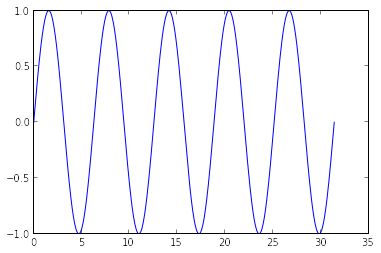

```python
x = np.linspace(0, 10 * np.pi, 500)
y = np.sin(x)
plot(x, y)
```

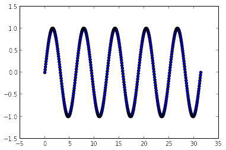

```python
scatter(x, y)
```

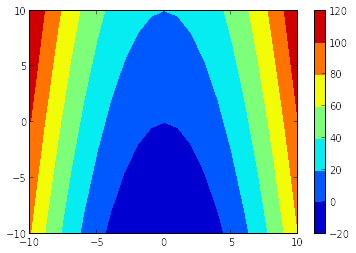

```python
x, y = np.meshgrid(np.linspace(-10, 10, 21), np.linspace(-10, 10, 21))
z = x ** 2 + 2 * y
contourf(x, y, z)
colorbar()
```

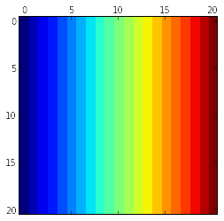

```python
matshow(x)
```

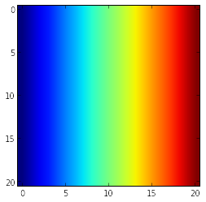

```python
imshow(x)
```

# scikit learn

- [Documentation](http://scikit-learn.org)

Example: Digits dataset

```python
from sklearn.datasets import load_digits
from sklearn.preprocessing import scale

digits = load_digits()
data = scale(digits.data)
```

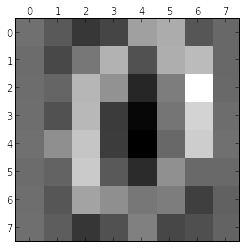

```python
matshow(data[10].reshape(8, 8))
gray()
```

Let's reduce the 64-dimensional vectors to 2 dimensions (dimensionality reduction)

```python
from sklearn.decomposition import PCA

reduced_data = PCA(n_components=2).fit_transform(data)
```

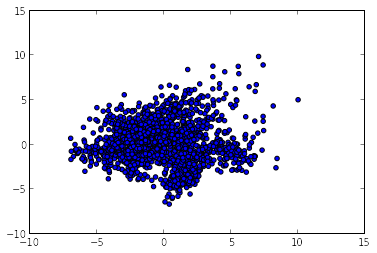

```python
scatter(reduced_data[:, 0], reduced_data[:, 1])
```

Is there any structure? Can we automatically determine **clusters**?

```python
from sklearn.cluster import KMeans

np.random.seed(42)

n_samples, n_features = data.shape
n_digits = len(np.unique(digits.target))

kmeans = KMeans(init='k-means++', n_clusters=n_digits, n_init=10)
kmeans.fit(reduced_data)
```

```
KMeans(copy_x=True, init='k-means++', max_iter=300, n_clusters=10, n_init=10,
    n_jobs=1, precompute_distances=True, random_state=None, tol=0.0001,
    verbose=0)
```

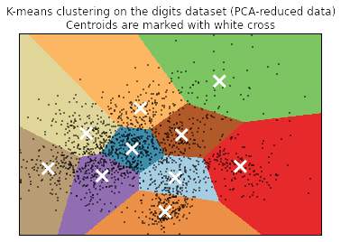

```python
# Step size of the mesh. Decrease to increase the quality of the VQ.
h = .02     # point in the mesh [x_min, m_max]x[y_min, y_max].

# Plot the decision boundary. For that, we will assign a color to each
x_min, x_max = reduced_data[:, 0].min() + 1, reduced_data[:, 0].max() - 1
y_min, y_max = reduced_data[:, 1].min() + 1, reduced_data[:, 1].max() - 1
xx, yy = np.meshgrid(np.arange(x_min, x_max, h), np.arange(y_min, y_max, h))

# Obtain labels for each point in mesh. Use last trained model.
Z = kmeans.predict(np.c_[xx.ravel(), yy.ravel()])

# Put the result into a color plot
Z = Z.reshape(xx.shape)
plt.figure(1)
plt.clf()
plt.imshow(Z, interpolation='nearest',
           extent=(xx.min(), xx.max(), yy.min(), yy.max()),
           cmap=plt.cm.Paired,
           aspect='auto', origin='lower')

plt.plot(reduced_data[:, 0], reduced_data[:, 1], 'k.', markersize=2)
# Plot the centroids as a white X
centroids = kmeans.cluster_centers_
plt.scatter(centroids[:, 0], centroids[:, 1],
            marker='x', s=169, linewidths=3,
            color='w', zorder=10)
plt.title('K-means clustering on the digits dataset (PCA-reduced data)\n'
          'Centroids are marked with white cross')
plt.xlim(x_min, x_max)
plt.ylim(y_min, y_max)
plt.xticks(())
plt.yticks(())
plt.show()
```